# CAH - TD - *correction*

## Données

La banque mondiale fournit un grand nombre de données, dont des indicateurs de gouvernance au niveau mondial (voir [ici](https://data.worldbank.org/data-catalog/worldwide-governance-indicators)). Nous allons travailler sur quelques uns comme ci-dessous.

| Country Name | CC.EST | GE.EST | PV.EST | RL.EST | RQ.EST | VA.EST |
| --- | --- | --- | --- | --- | --- | --- |
| Afghanistan | -1.5637351 | -1.2221063 | -2.7491674 | -1.6164296 | -1.3279194 | -1.0862195 |
| Albania | -0.3975671 | -0.0005732 | 0.2577201 | -0.3474675 | 0.1889622 | 0.1591910 |
| Algeria | -0.6913593 | -0.5446945 | -1.1392820 | -0.8493193 | -1.1718426 | -0.8772413 |
| Andorra | 1.2303408 | 1.8602008 | 1.3960468 | 1.5640105 | 0.8714089 | 1.1975403 |
| Angola | -1.4118286 | -1.0393770 | -0.3866403 | -1.0805222 | -1.0013810 | -1.1673551 |
| Antigua and Barbuda | 0.6922924 | 0.2657260 | 1.0138445 | 0.5093514 | 0.3413707 | 0.6460172 |

## CAH sur les données d’origine

Nous appliquons la CAH directement sur les données, car les variables ont toutes une moyenne proche de 0 et un écart-type proche de 1. Nous utilisons la distance euclidienne et testons les trois méthodes d’agrégation suivantes : complet, simple et Ward.

Nous obtenons ainsi les trois dendrogrammes suivants. L’arbre obtenu pour le lien simple est très difficilement lisible. Il semble qu’il ne dégage pas réellement une structure en classes. Pour le lien complet, nous pouvons hésiter entre 2, 3 et 4 classes. Pour le critère de Ward, le choix se limite à 2 classes ou 4 classes.

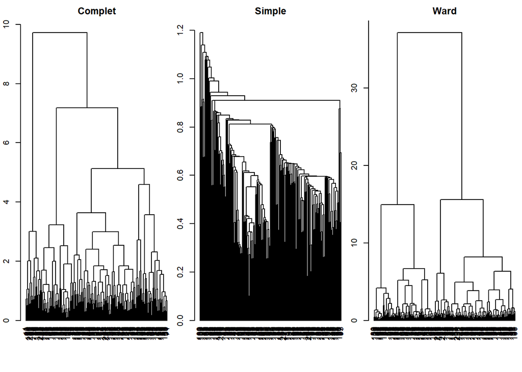

Il est possible de calculer automatiquement les valeurs de $R^2$ et de $PseudoF$. Dans ce cas, nous en déduisons les nombres de classes suivants pour chaque méthode :

- *Complet* : 4 classes ($PseudoF$ maximum)
- *Simple* : 5 classes (idem et palier sur le $R^2$)
- *Ward* : 2 ($PseudoF$ maximum) ou 4 classes (pic sur le $PseudoF$)

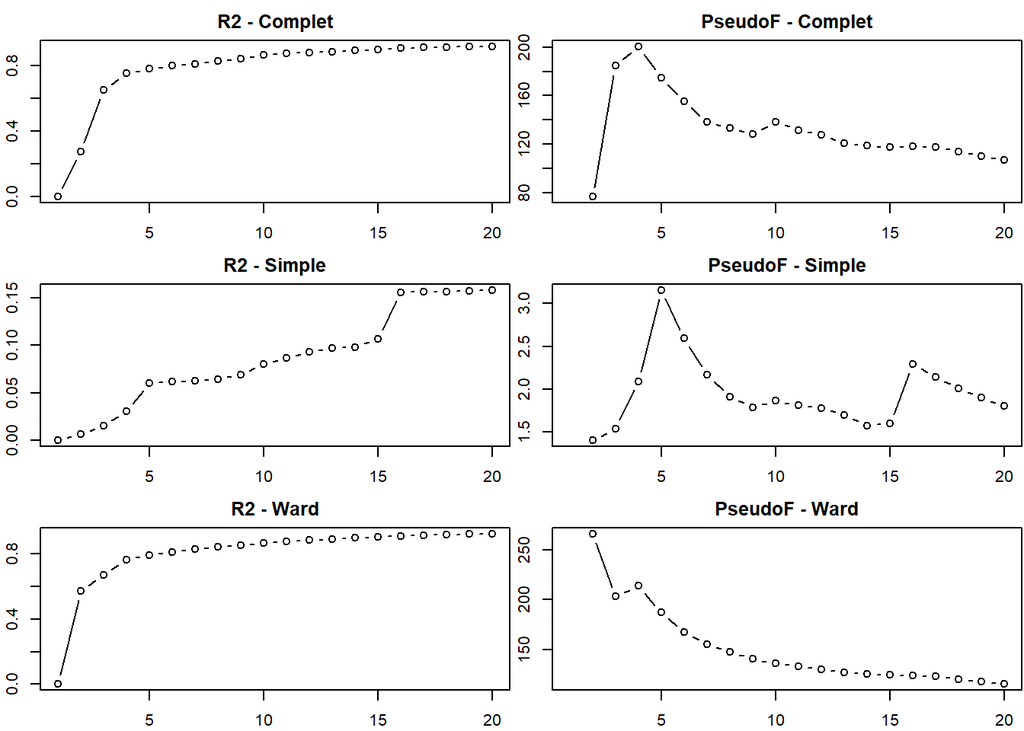

Nous en déduisons donc les partitions, avec les moyennes pour chaque variable comme ci-dessous.

- Lien complet en 4 classes

  | CC.EST | GE.EST | PV.EST | RL.EST | RQ.EST | VA.EST |
  | --- | --- | --- | --- | --- | --- |
  | -1.4363115 | -1.5308556 | -1.5157827 | -1.5839401 | -1.5971176 | -1.5124553 |
  | -0.5749560 | -0.5103078 | -0.4515216 | -0.5555268 | -0.4611046 | -0.3616565 |
  | 1.3340962 | 1.4003124 | 0.8919512 | 1.4071303 | 1.4027292 | 1.0914531 |
  | 0.3527503 | 0.2210881 | 0.5652074 | 0.3502663 | 0.1810685 | 0.3257220 |

- Lien simple en 5 classes

  | CC.EST | GE.EST | PV.EST | RL.EST | RQ.EST | VA.EST |
  | --- | --- | --- | --- | --- | --- |
  | -0.0766465 | -0.0763885 | -0.0594383 | -0.0645509 | -0.0757252 | 0.0217680 |
  | 0.8058025 | 0.8557424 | 0.8426037 | 0.7027083 | 0.7181886 | -1.0941971 |
  | 1.8239339 | 2.0347642 | 1.1850819 | 1.7636361 | 2.1673964 | -0.0073626 |
  | 0.8330753 | 1.1779573 | 1.4151092 | 0.8270391 | 1.7814498 | -0.0559072 |
  | -0.1740915 | -0.2854885 | -2.0480635 | -0.2340371 | 0.1304355 | -0.9020127 |

- Critère de Ward en 2 classes

  | CC.EST | GE.EST | PV.EST | RL.EST | RQ.EST | VA.EST |
  | --- | --- | --- | --- | --- | --- |
  | -0.7106032 | -0.6687072 | -0.6567765 | -0.7184514 | -0.6490418 | -0.6237548 |
  | 0.8906326 | 0.8422969 | 0.8050685 | 0.9211478 | 0.8302681 | 0.8344598 |

- Critère de Ward en 4 classes

  | CC.EST | GE.EST | PV.EST | RL.EST | RQ.EST | VA.EST |
  | --- | --- | --- | --- | --- | --- |
  | -1.4257517 | -1.4922441 | -1.4291504 | -1.5404028 | -1.5543148 | -1.4833957 |
  | -0.5260487 | -0.4561816 | -0.4574541 | -0.5063349 | -0.4154229 | -0.4019120 |
  | 1.6606932 | 1.5590918 | 0.9469898 | 1.6135652 | 1.5857160 | 1.1588774 |
  | 0.4485609 | 0.4308036 | 0.7235952 | 0.5236490 | 0.3965850 | 0.6482201 |

Bien évidemment, il est plus lisible de projeter ces partitions sur le premier plan factoriel de l’ACP (qui représente 91% de l’information). On voit que la partition obtenue avec le lien simple n’est pas du tout informative dans ce cas. Les partitions obtenues via le lien complet ou le critère de Ward avec 4 classes semblent très proches. La partition à 2 classes via Ward est moins fine.

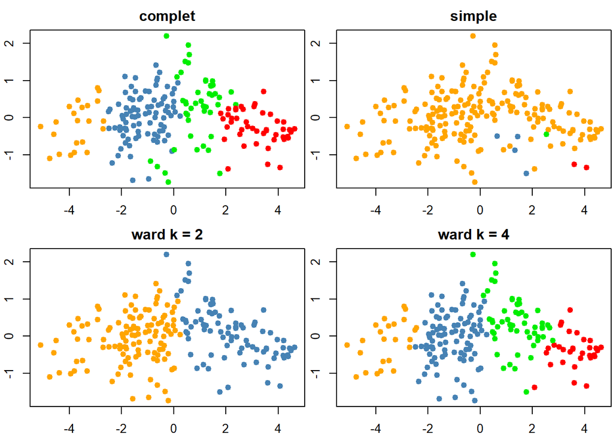

Voici les pays contenus dans chaque classe (ainsi que la moyenne des variables), de la partition de Ward en 4 classes.

- Classe 1 : Afghanistan; Angola; Burundi; Central African Republic; Chad; Congo, Dem. Rep.; Congo, Rep.; Equatorial Guinea; Eritrea; Guinea-Bissau; Haiti; Iraq; Korea, Dem. People’s Rep.; Libya; Somalia; South Sudan; Sudan; Syrian Arab Republic; Tajikistan; Turkmenistan; Uzbekistan; Venezuela, RB; Yemen, Rep.; Zimbabwe

  | CC.EST | GE.EST P | V.EST | RL.EST | RQ.EST | VA.EST |
  | --- | --- | --- | --- | --- | --- |
  | -1.425752 | -1.492244 | -1.42915 | -1.540403 | -1.554315 | -1.483396 |

- Classe 2 : Albania; Algeria; Argentina; Armenia; Azerbaijan; Bahrain; Bangladesh; Belarus; Belize; Benin; Bolivia; Bosnia and Herzegovina; Brazil; Burkina Faso; Cambodia; Cameroon; China; Colombia; Comoros; Cote d’Ivoire; Cuba; Djibouti; Dominican Republic; Ecuador; Egypt, Arab Rep.; El Salvador; Ethiopia; Fiji; Gabon; Gambia, The; Ghana; Guatemala; Guinea; Guyana; Honduras; India; Indonesia; Iran, Islamic Rep.; Jordan; Kazakhstan; Kenya; Kosovo; Kuwait; Kyrgyz Republic; Lao PDR; Lebanon; Lesotho; Liberia; Macedonia, FYR; Madagascar; Malawi; Maldives; Mali; Mauritania; Mexico; Moldova; Mongolia; Montenegro; Morocco; Mozambique; Myanmar; Nauru; Nepal; Nicaragua; Niger; Nigeria; Pakistan; Papua New Guinea; Paraguay; Peru; Philippines; Russian Federation; Rwanda; Sao Tome and Principe; Saudi Arabia; Senegal; Serbia; Sierra Leone; Solomon Islands; Sri Lanka; Suriname; Swaziland; Tanzania; Thailand; Timor-Leste; Togo; Tunisia; Turkey; Uganda; Ukraine; Vietnam; West Bank and Gaza; Zambia

  | CC.EST | GE.EST | PV.EST | RL.EST | RQ.EST | VA.EST |
  | --- | --- | --- | --- | --- | --- |
  | -0.5260487 | -0.4561816 | -0.4574541 | -0.5063349 | -0.4154229 | -0.401912 |

- Classe 3 : Andorra; Aruba; Australia; Austria; Belgium; Canada; Chile; Denmark; Estonia; Finland; France; French Guiana; Germany; Greenland; Hong Kong SAR, China; Iceland; Ireland; Israel; Japan; Jersey, Channel Islands; Liechtenstein; Luxembourg; Macao SAR, China; Netherlands; New Zealand; Norway; Singapore; Sweden; Switzerland; United Kingdom; United States

| CC.EST | GE.EST | PV.EST | RL.EST | RQ.EST | VA.EST |
| --- | --- | --- | --- | --- | --- |
| 1.660693 | 1.559092 | 0.9469898 | 1.613565 | 1.585716 | 1.158877 |

- Classe 4 : Antigua and Barbuda; Bahamas, The; Barbados; Bhutan; Botswana; Brunei Darussalam; Bulgaria; Cabo Verde; Cayman Islands; Costa Rica; Croatia; Cyprus; Czech Republic; Dominica; Georgia; Greece; Grenada; Hungary; Italy; Jamaica; Kiribati; Korea, Rep.; Latvia; Lithuania; Malaysia; Malta; Marshall Islands; Mauritius; Micronesia, Fed. Sts.; Namibia; Oman; Palau; Panama; Poland; Portugal; Puerto Rico; Qatar; Romania; Samoa; Seychelles; Slovak Republic; Slovenia; South Africa; Spain; St. Kitts and Nevis; St. Lucia; St. Vincent and the Grenadines; Taiwan, China; Tonga; Trinidad and Tobago; Tuvalu; United Arab Emirates; Uruguay; Vanuatu

  | CC.EST | GE.EST | PV.EST R | L.EST R | Q.EST | VA.EST |
  | --- | --- | --- | --- | --- | --- |
  | 0.4485609 | 0.4308036 | 0.7235952 | 0.523649 | 0.396585 | 0.6482201 |

Il est possible de comparer plus finement les classes de manière graphique, avec des boîtes à moustaches.

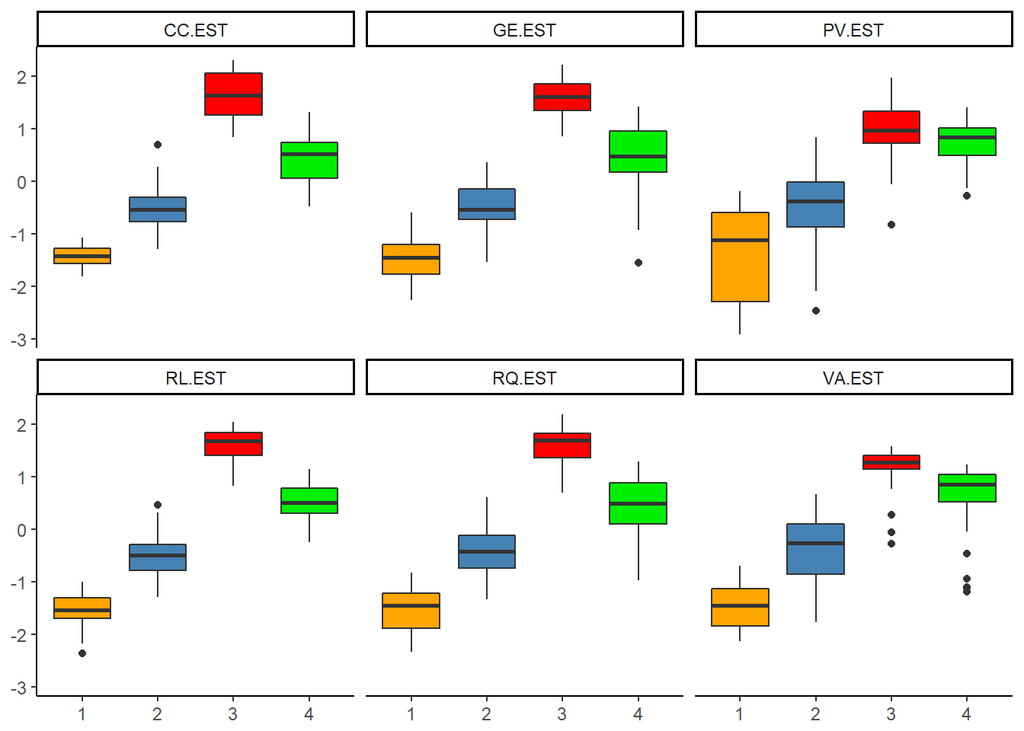

## Et sur les résultats de l’ACP

En appliquant la CAH sur les coordonnées obtenues après l’ACP (3 axes retenus pour 96% de variance expliquée). En regardant les résultats, nous voyons qu’il est possible de soit couper en 2 classes, soit en 4 classes (mais de manière moins marquée que précédemment). Nous faisons le choix ici de conserver 4 classes, pour plus de finesse de la partition.

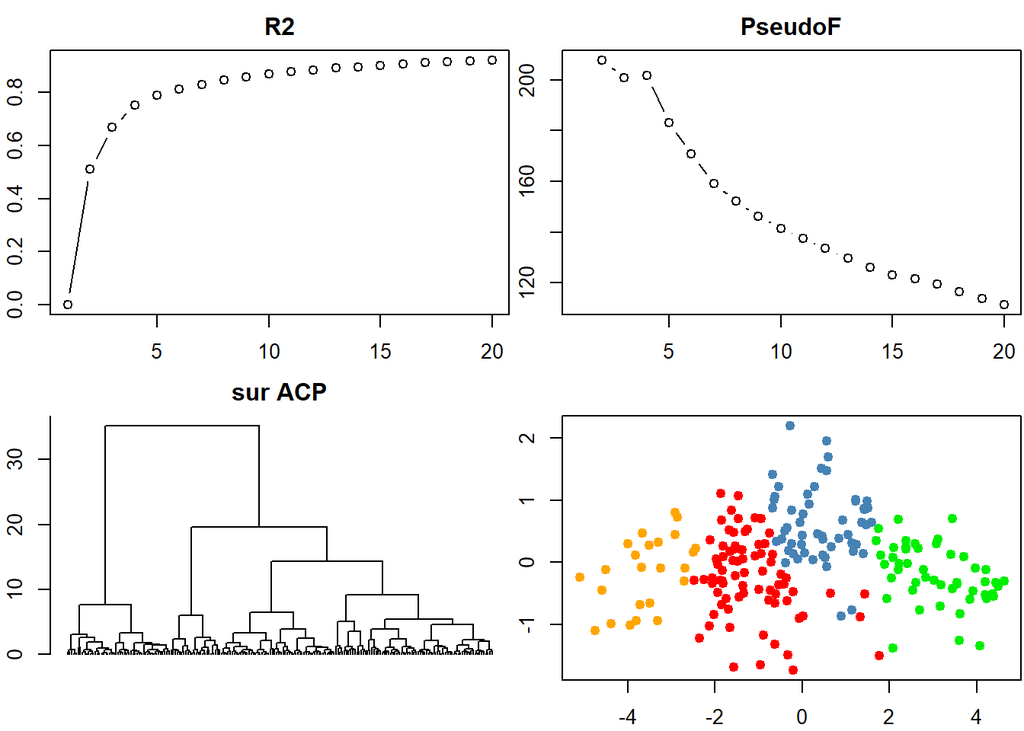

La partition obtenue semble sensiblement différente de celle obtenue avec le critère de Ward sur l’ensemble des variables. En regardant le croisement de ces deux partitions, nous remarquons qu’elles diffèrent sur 44 individus.

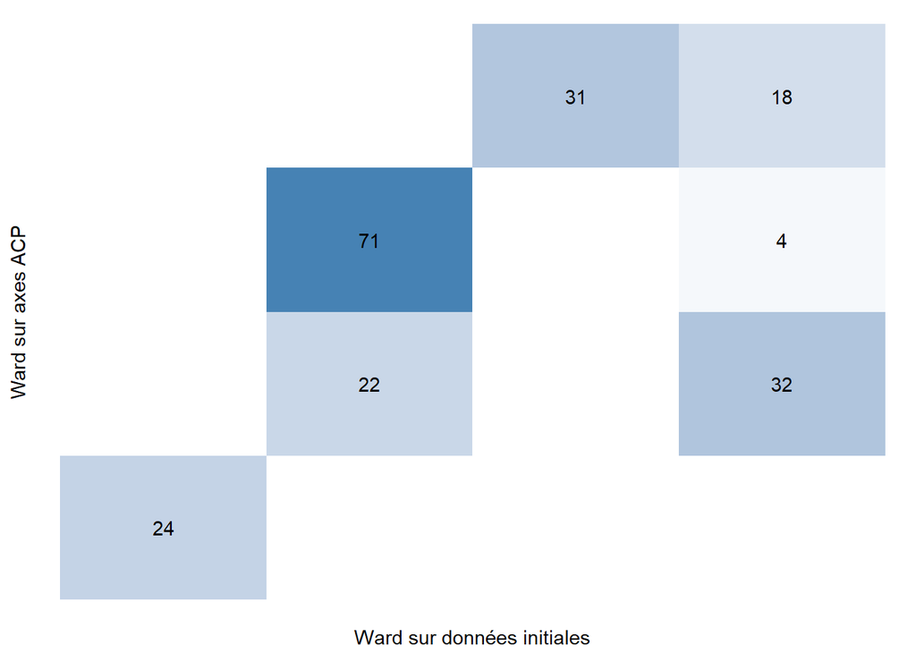